# Synthetic campaign pipeline simulation

Suppose your institution is planning a campaign and leadership wants to know how risky it is to only have one naming-gift-level donor in the solicitation pipeline.

Create some synthetic data under four different scenarios: high variance with a single very large gift and multiple small ones, followed by medium, low, and no variance pipelines where the range of solicitations becomes smaller and smaller.

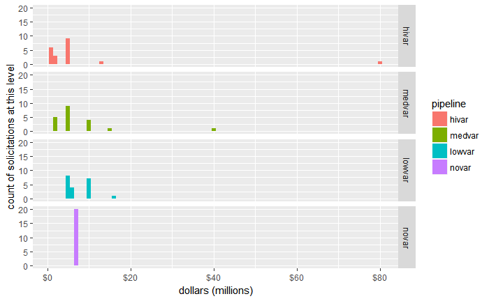

This represents 4 different campaigns, with MG pipelines of 20 gifts summing up to $150M in asks. Note that all synthetic pipelines have the same number of proposals and the same mean:

|  | n | StDev | min | median | mean | max |
| --- | --- | --- | --- | --- | --- | --- |
| hivar | 20 | 17.300745 | 1.0 | 5.0 | 7.5 | 80.0 |
| medvar | 20 | 8.413648 | 2.0 | 5.0 | 7.5 | 40.0 |
| lowvar | 20 | 3.034885 | 5.0 | 6.0 | 7.5 | 16.0 |
| novar | 20 | 0.000000 | 7.5 | 7.5 | 7.5 | 7.5 |

Let’s run a Monte Carlo simulation to see what outcomes might be expected for each of these campaigns.

Assume all proposals have a $p =$ 0.333 chance of closing at the expected value, and the probabilities are all independent, so that one proposal closing or not doesn’t affect the next.

Here are results for 2500 simulations of each campaign under those assumptions.

|  | n | StDev | min | median | mean | max |
| --- | --- | --- | --- | --- | --- | --- |
| hivar | 2500 | 38.89801 | 1.0 | 30.0 | 50.0708 | 131 |
| medvar | 2500 | 23.33495 | 2.0 | 46.0 | 49.9864 | 119 |
| lowvar | 2500 | 16.78444 | 5.0 | 48.5 | 49.9172 | 103 |
| novar | 2500 | 15.44597 | 7.5 | 52.5 | 49.9290 | 105 |

Plotting the results of the simulation:

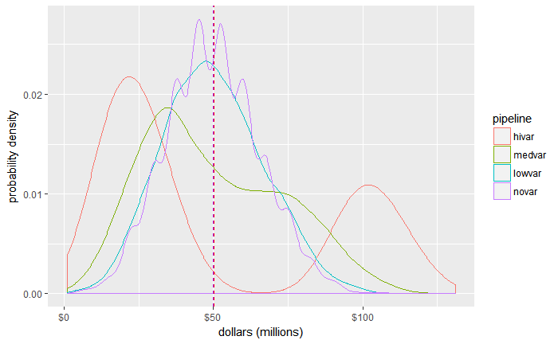

Though all campaigns are expected to raise $50M on average, the success of the high-variance pipeline campaign depends almost entirely on the single $80M proposal. Specifically, in any given simulation there is a 66.7% chance this gift does not come in, and when it doesn’t, making the $50M goal is very unlikely. In fact, out of the 1662 simulations where the $80M gift did not close, only 6 exceeded the $50M expected value (mean).

In the high-variance situation, reporting that the expected campaign outcome is $50M *is nearly meaningless!* High variance implies low confidence.

## Session Info

```
 setting  value
 version  R version 3.3.3 (2017-03-06)
 system   x86_64, mingw32
 ui       RStudio (1.0.136)
 language (EN)
 collate  English_United States.1252
 tz       America/New_York
 date     2018-06-19
```